# Credit Card Fraud Detection

## Setup

```r
credit = read.csv("./creditcard.csv")
```

## Examine Data

```r
table(credit$Class)
```

```
##
##      0      1
## 284315    492
```

```r
table(credit$Class)/nrow(credit)
```

```
##
##           0           1
## 0.998272514 0.001727486
```

The given data is heavily skewed, with only 0.172% of fraud cases. We have to deal with this imbalance.

## Preprocess

```r
# scale Time and Amount
credit$Time = as.numeric(scale(credit$Time))
credit$Amount = as.numeric(scale(credit$Amount))
```

## Split Data

```r
nfraud = subset(credit, Class == "0")
fraud = subset(credit, Class == "1")

set.seed(99)
nfraud_index = sample(nrow(nfraud), 0.7 * nrow(nfraud), replace = FALSE)
fraud_index = sample(nrow(fraud), 0.7 * nrow(fraud), replace = FALSE)

nfraud_train = nfraud[nfraud_index, ]
nfraud_test = nfraud[-nfraud_index, ]
fraud_train = fraud[fraud_index, ]
fraud_test = fraud[-fraud_index, ]

train = rbind(nfraud_train, fraud_train)
test = rbind(nfraud_test, fraud_test)
```

Stratified random sampling

## PCA for Test Data

```r
pca_test = prcomp(test[, -31])
test_1 = pca_test$x[, 1] # PCA1
test_2 = pca_test$x[, 2] # PCA2
```

The given data includes Amount and Time, which are not part of previously done PCA. For the sake of visualization, we will conduct another PCA including all given variables.

# Undersample

One way to deal with imbalanced data is to undersample. I will randomly choose 492 non-frauds and combine with frauds. This will make new data with size of 984, that has 50:50 distribution between non-frauds and frauds.

```r
library(dplyr)
set.seed(11)
nonf = sample_n(credit[credit$Class == 0, ], size = sum(credit$Class == 1))
df = rbind(nonf, credit[credit$Class == 1, ])
```

## Examine corr

The new balanced data will tell differently about the data. Here, let’s look at the correlation between each PCA variables and whether fraud.

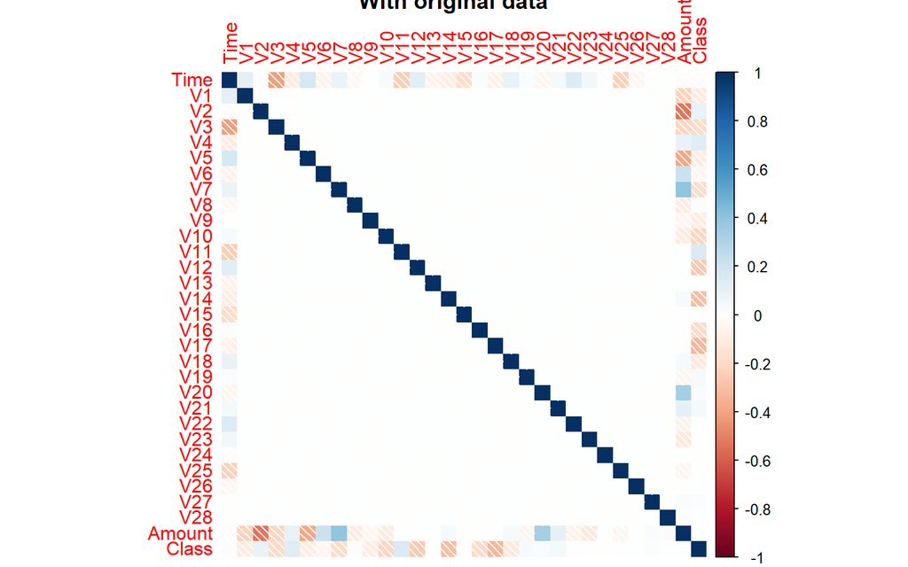

```r
library(corrplot)
corrplot(cor(credit), method = "shade", title = "With original data")
```

[figure not shown]

```r
corrplot(cor(df), method = "shade", title = "With balanced data")
```

The original data shows only vague correlations. In contrast, the new balanced data shows much clearer correlations.  
Specifically,  
- V2, V4, and V11 have positive correlation with Class.  
- V3, V9, V10, V12, V14, and V16 have negative correlation with Class.

## Anomaly detection

For the variables found to have strong correlations with Class, let’s proceed to find outliers and remove them. This will affect the accuracy performance of prediction.  
For anomaly detection, we will use 1.5 IQR barrier to decide which to keep and drop.

```r
new_df = df

anomaly_report = data.frame('Var' = 0, 'Upper' = 0, 'Lower' = 0, 'outliers' = 0)

var_index = c(2, 3, 4, 9, 10, 11, 12, 14, 16)
index = rep(1, nrow(new_df))
for (i in 1:9) {
  q1 = summary(new_df[, var_index[i]+1])[2]
  q3 = summary(new_df[, var_index[i]+1])[5]
  iqr = q3 - q1
  cutoff = iqr * 1.5
  lower = q1 - cutoff
  upper = q3 + cutoff

  outlier = new_df[, var_index[i]+1] < lower | new_df[, var_index[i]+1] > upper

  index = index * !outlier

  anomaly_report[i, 1] = paste("V", var_index[i], sep = "")
  anomaly_report[i, 2] = lower
  anomaly_report[i, 3] = upper
  anomaly_report[i, 4] = sum(outlier)
}

new_df = new_df[as.logical(index), ]

print(anomaly_report)
```

```
##   Var      Upper     Lower outliers
## 1  V2  -4.710133  7.480000       82
## 2  V3 -13.409596  8.625005       78
## 3  V4  -6.536974 10.810762       17
## 4  V9  -6.057394  3.954643       55
## 5 V10 -11.470783  6.869891       81
## 6 V11  -6.135685  9.419220       18
## 7 V12 -14.016298  8.706575       44
## 8 V14 -16.987124 10.387076        8
## 9 V16  -9.349516  6.133391       62
```

## Clustering

### t-SNE

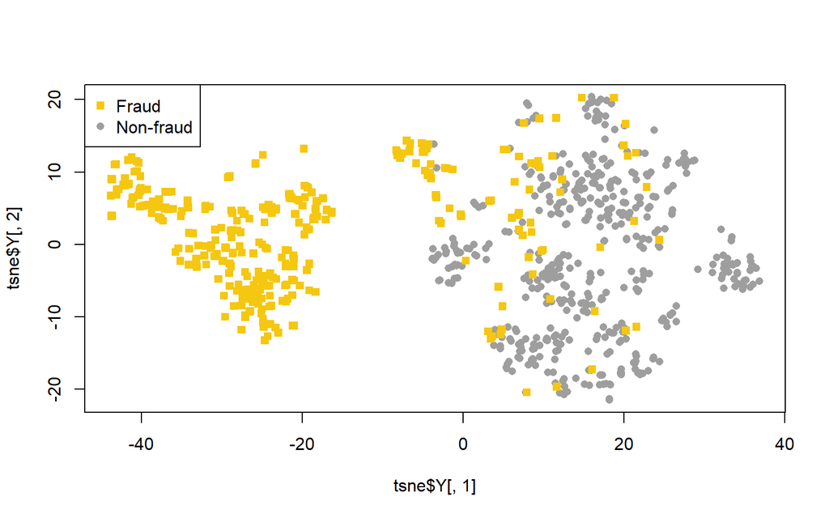

```r
X = new_df[, -31]
y = new_df[, 31]

clus = ifelse(y == 1, 15, 16)

library(Rtsne)
tsne = Rtsne(X, dims = 2, check_duplicates = FALSE, normalize = FALSE)
plot(tsne$Y[, 1], tsne$Y[, 2], pch = clus, col = clus)
legend("topleft", legend = c("Fraud", "Non-fraud"), pch = c(15, 16), col = c(15, 16))
```

On the left side, we can clearly see a cluster, consist only of frauds. However, on the right side, frauds and non-frauds are mixed together.

### PCA

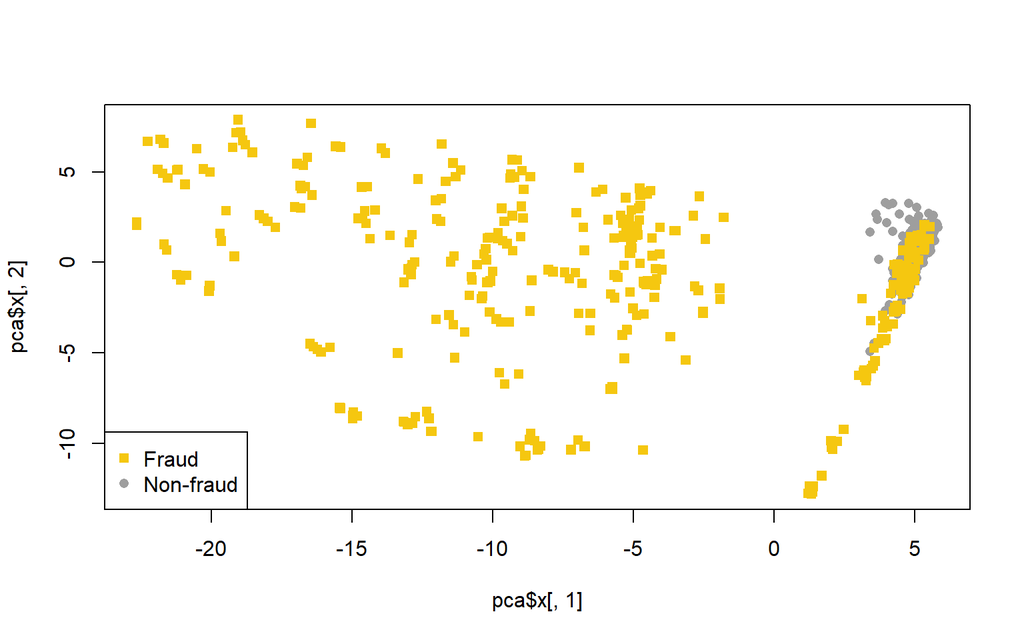

```r
pca = prcomp(new_df[, -31])

plot(pca$x[, 1], pca$x[, 2], pch = clus, col = clus)
legend("bottomleft", legend = c("Fraud", "Non-fraud"), pch = c(15, 16), col = c(15, 16))
```

### FA

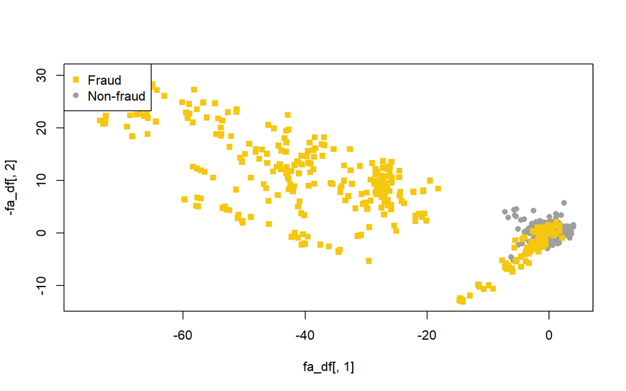

```r
fa = factanal(new_df[, -31], 2, rotation = "varimax")

fa_df = as.matrix(new_df[, -31]) %*% as.matrix(fa$loadings)

plot(fa_df[, 1], -fa_df[, 2], pch = clus, col = clus)
legend("topleft", legend = c("Fraud", "Non-fraud"), pch = c(15, 16), col = c(15, 16))
```

PCA and FA show similar visualization, possibly related to t-SNE. We can see fraud cases on the left, distinct from non-frauds. Yet, on the right side, non-frauds are mixed with frauds, hard to distiguish from each other.

## Classifier

### Logistic Regression

```r
lr = glm(Class ~ ., new_df, family = "binomial")
```

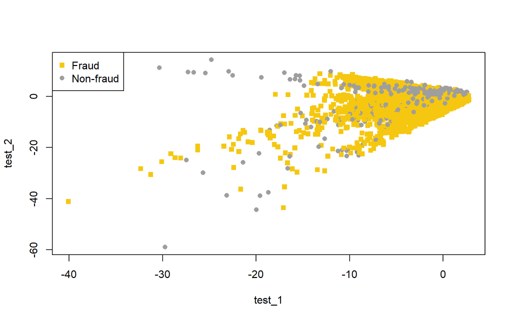

```r
pred_lr = predict(lr, newdata = test, type = "response")
lr_index = as.numeric(pred_lr > 0.9) # cutoff

plot(test_1, test_2, pch = lr_index+15, col = lr_index+15)
legend("topleft", legend = c("Fraud", "Non-fraud"), pch = c(15, 16), col = c(15, 16))

library(caret)
```

```r
lr_confmat = confusionMatrix(as.factor(lr_index), as.factor(test$Class), positive = "1")
lr_confmat
```

```
## Confusion Matrix and Statistics
##
##           Reference
## Prediction     0     1
##          0 84432    16
##          1   863   132
##
##                Accuracy : 0.9897
##                  95% CI : (0.989, 0.9904)
##     No Information Rate : 0.9983
##     P-Value [Acc > NIR] : 1
##
##                   Kappa : 0.2286
##
##  Mcnemar's Test P-Value : <2e-16
##
##             Sensitivity : 0.891892
##             Specificity : 0.989882
##          Pos Pred Value : 0.132663
##          Neg Pred Value : 0.999811
##              Prevalence : 0.001732
##          Detection Rate : 0.001545
##    Detection Prevalence : 0.011645
##       Balanced Accuracy : 0.940887
##
##        'Positive' Class : 1
##
```

```r
library(pROC)
lr_roc = roc(test$Class ~ pred_lr)
```

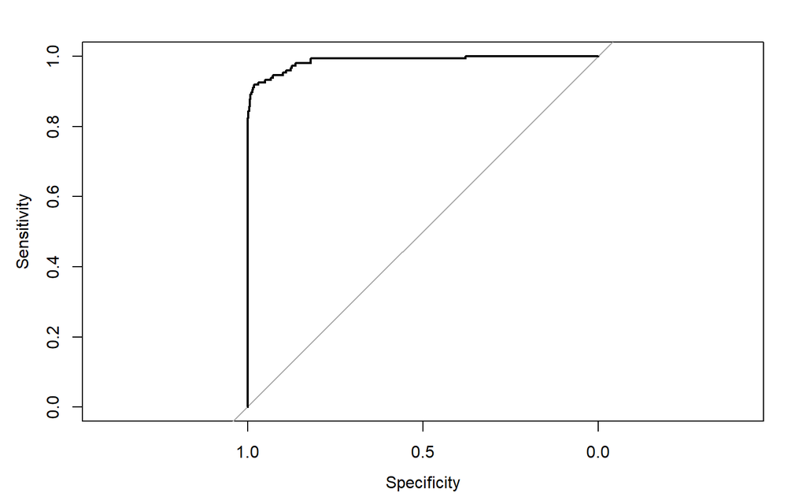

```r
plot(lr_roc)
```

### Lasso Regression

```r
library(glmnet)
```

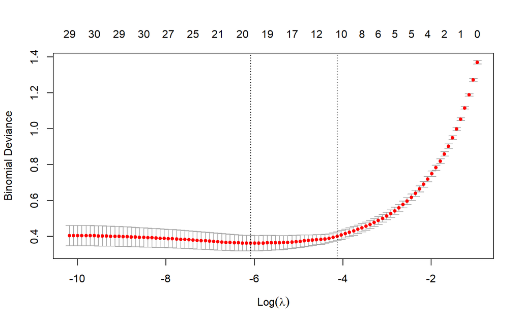

```r
set.seed(11)

x_glm = model.matrix(Class ~ ., new_df)[, -1]

cv_lasso = cv.glmnet(x_glm, new_df$Class, alpha = 1, family = "binomial")
plot(cv_lasso)
```

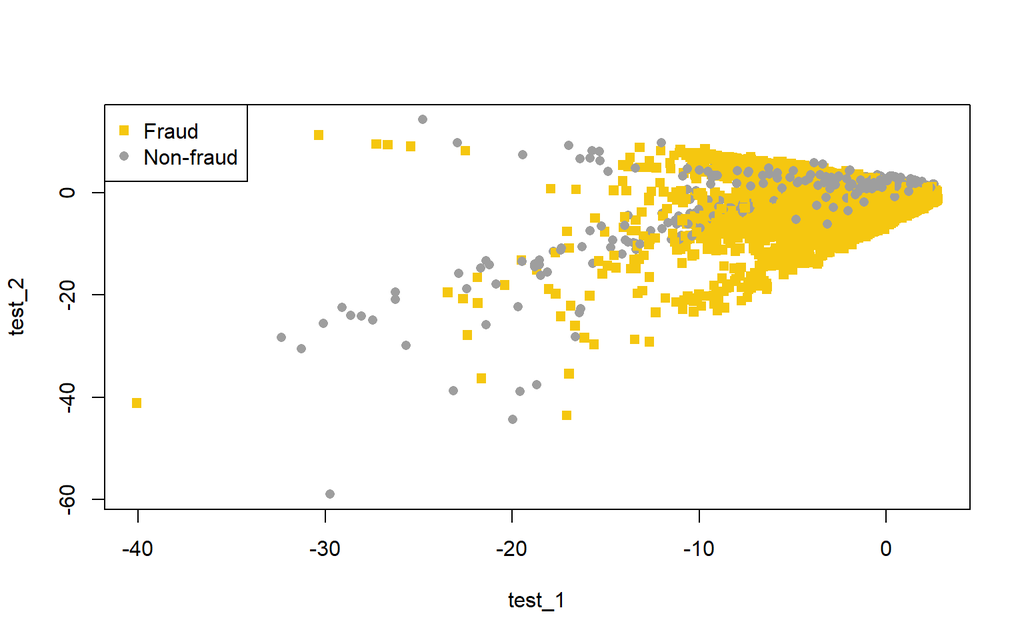

```r
lasso = glmnet(x_glm, new_df$Class, alpha = 1, family = "binomial", lambda = cv_lasso$lambda.min)

x_test = model.matrix(Class ~ ., test)[, -1]
pred_lasso = predict(lasso, newx = x_test, type = "response")
lasso_index = as.numeric(pred_lasso > .99)

plot(test_1, test_2, pch = lasso_index+15, col = lasso_index+15)
legend("topleft", legend = c("Fraud", "Non-fraud"), pch = c(15, 16), col = c(15, 16))
```

```r
lasso_confmat = confusionMatrix(as.factor(lasso_index), as.factor(test$Class), positive = "1")
lasso_confmat
```

```
## Confusion Matrix and Statistics
##
##           Reference
## Prediction     0     1
##          0 85122    32
##          1   173   116
##
##                Accuracy : 0.9976
##                  95% CI : (0.9972, 0.9979)
##     No Information Rate : 0.9983
##     P-Value [Acc > NIR] : 1
##
##                   Kappa : 0.5298
##
##  Mcnemar's Test P-Value : <2e-16
##
##             Sensitivity : 0.783784
##             Specificity : 0.997972
##          Pos Pred Value : 0.401384
##          Neg Pred Value : 0.999624
##              Prevalence : 0.001732
##          Detection Rate : 0.001358
##    Detection Prevalence : 0.003382
##       Balanced Accuracy : 0.890878
##
##        'Positive' Class : 1
##
```

```r
lasso_roc = roc(test$Class ~ pred_lasso)
```

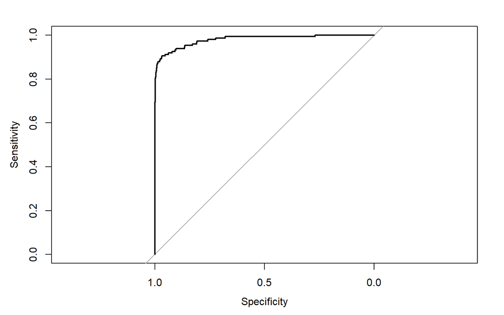

```r
plot(lasso_roc)
```

### Naive Bayes

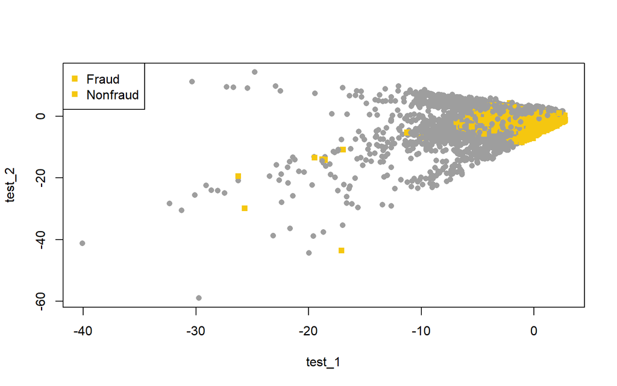

```r
nb_df = new_df
nb_df$Class = as.factor(new_df$Class)

library(e1071)

nb = naiveBayes(Class ~ ., nb_df, type = "class")

pred_nb = predict(nb, newdata = test, type = "class")

nb_index = as.numeric(pred_nb) -1
plot(test_1, test_2, pch = nb_index+15, col = nb_index+15)
legend("topleft", legend = c("Fraud", "Nonfraud"), pch = nb_index+15, col = nb_index+15)
```

```r
nb_confmat = confusionMatrix(pred_nb, as.factor(test$Class), positive = "1")
nb_confmat
```

```
## Confusion Matrix and Statistics
##
##           Reference
## Prediction     0     1
##          0 82105    20
##          1  3190   128
##
##                Accuracy : 0.9624
##                  95% CI : (0.9611, 0.9637)
##     No Information Rate : 0.9983
##     P-Value [Acc > NIR] : 1
##
##                   Kappa : 0.0708
##
##  Mcnemar's Test P-Value : <2e-16
##
##             Sensitivity : 0.864865
##             Specificity : 0.962600
##          Pos Pred Value : 0.038577
##          Neg Pred Value : 0.999756
##              Prevalence : 0.001732
##          Detection Rate : 0.001498
##    Detection Prevalence : 0.038833
##       Balanced Accuracy : 0.913733
##
##        'Positive' Class : 1
##
```

```r
nb_roc = roc(test$Class, nb_index)
```

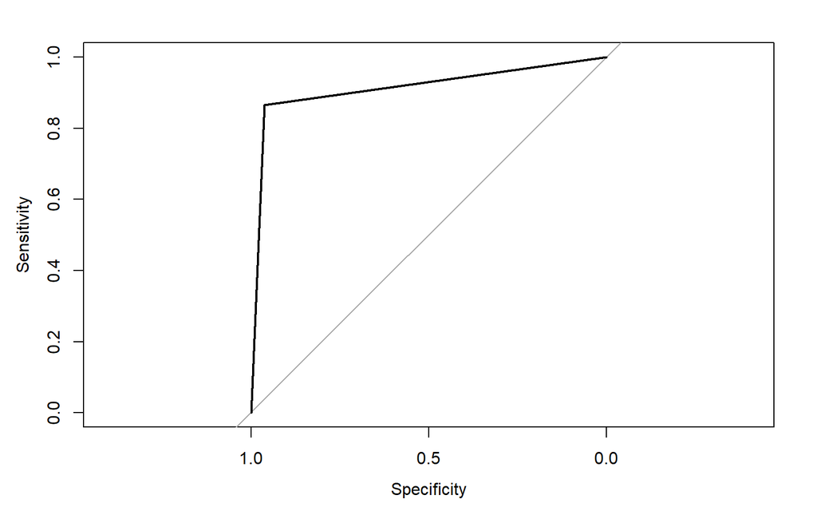

```r
plot(nb_roc)
```

### SVM

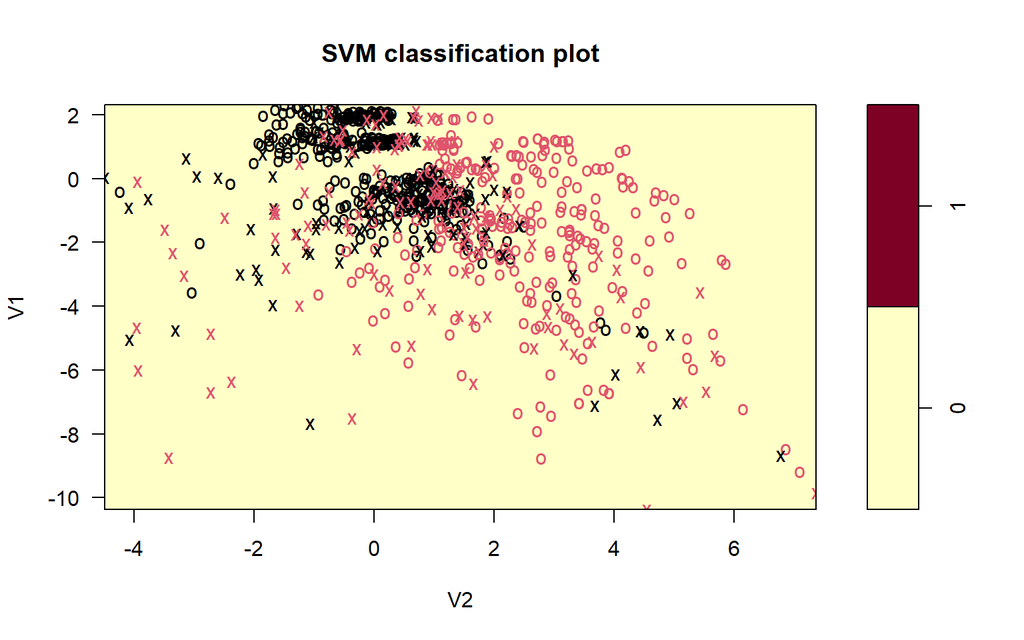

```r
svm = svm(Class ~ ., nb_df)
plot(svm, nb_df, V1 ~ V2)
```

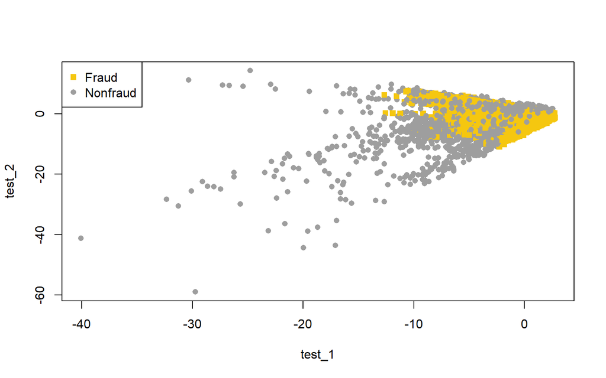

```r
pred_svm = predict(svm, test)

svm_index = as.numeric(pred_svm) - 1
plot(test_1, test_2, pch = svm_index+15, col = svm_index+15)
legend("topleft", legend = c("Fraud", "Nonfraud"), pch = c(15, 16), col = c(15, 16))
```

```r
svm_confmat = confusionMatrix(pred_svm, as.factor(test$Class), positive = "1")
svm_confmat
```

```
## Confusion Matrix and Statistics
##
##           Reference
## Prediction     0     1
##          0 83085    10
##          1  2210   138
##
##                Accuracy : 0.974
##                  95% CI : (0.9729, 0.9751)
##     No Information Rate : 0.9983
##     P-Value [Acc > NIR] : 1
##
##                   Kappa : 0.1077
##
##  Mcnemar's Test P-Value : <2e-16
##
##             Sensitivity : 0.932432
##             Specificity : 0.974090
##          Pos Pred Value : 0.058773
##          Neg Pred Value : 0.999880
##              Prevalence : 0.001732
##          Detection Rate : 0.001615
##    Detection Prevalence : 0.027480
##       Balanced Accuracy : 0.953261
##
##        'Positive' Class : 1
##
```

```r
svm_roc = roc(test$Class, svm_index)
```

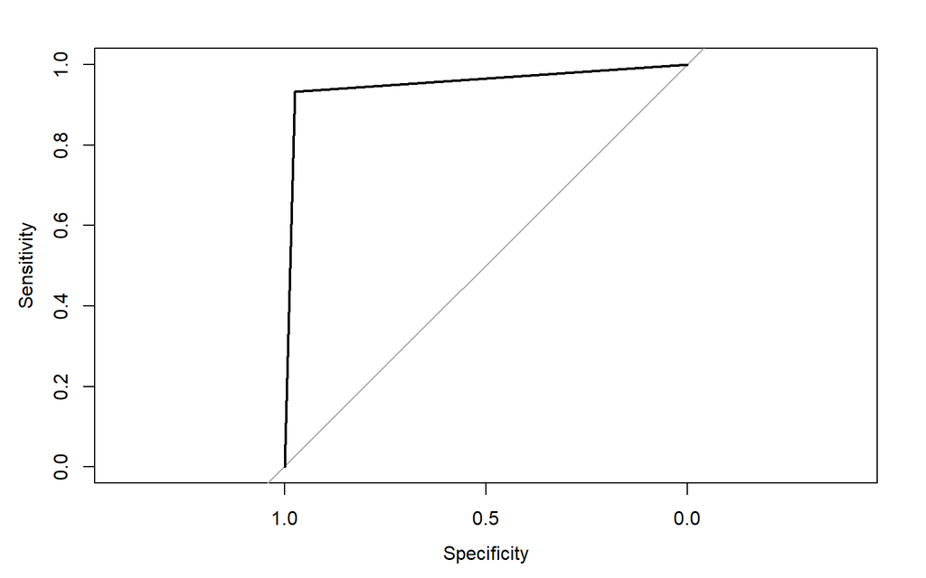

```r
plot(svm_roc)
```

### Decision Tree

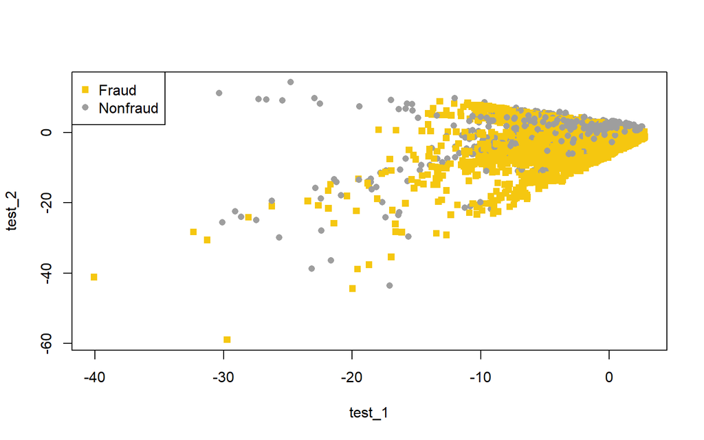

```r
library(rpart)

dt = rpart(Class ~ ., new_df, method = "class")

pred_dt = predict(dt, newdata = test, type = "class")

dt_index = as.numeric(pred_dt) - 1
plot(test_1, test_2, pch = dt_index+15, col = dt_index+15)
legend("topleft", legend = c("Fraud", "Nonfraud"), pch = c(15, 16), col = c(15, 16))
```

```r
dt_confmat = confusionMatrix(pred_dt, as.factor(test$Class), positive = "1")
dt_confmat
```

```
## Confusion Matrix and Statistics
##
##           Reference
## Prediction     0     1
##          0 82553    15
##          1  2742   133
##
##                Accuracy : 0.9677
##                  95% CI : (0.9665, 0.9689)
##     No Information Rate : 0.9983
##     P-Value [Acc > NIR] : 1
##
##                   Kappa : 0.085
##
##  Mcnemar's Test P-Value : <2e-16
##
##             Sensitivity : 0.898649
##             Specificity : 0.967853
##          Pos Pred Value : 0.046261
##          Neg Pred Value : 0.999818
##              Prevalence : 0.001732
##          Detection Rate : 0.001557
##    Detection Prevalence : 0.033648
##       Balanced Accuracy : 0.933251
##
##        'Positive' Class : 1
##
```

```r
dt_roc = roc(test$Class, dt_index)
```

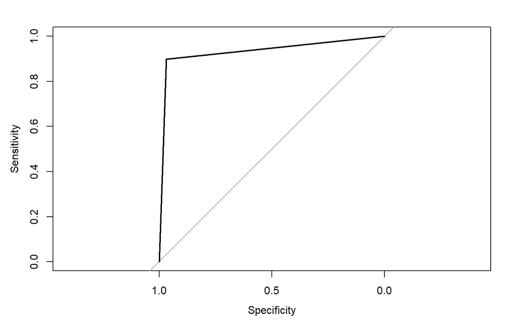

```r
plot(dt_roc)
```

### kNN

```r
library(FNN)

knn_perf = data.frame(k = 1:5, acc = 0, sens = 0)
for (i in 1:5) {
  fit = knn(new_df[, -31], test[, -31], new_df[, 31], k = i)
  confmat = confusionMatrix(as.factor(fit), as.factor(test$Class), positive = "1")
  knn_perf[i, ] = c(i, confmat$overall['Accuracy'], confmat$byClass['Sensitivity'])
}
knn_perf
```

```
##   k       acc      sens
## 1 1 0.9402058 0.9932432
## 2 2 0.9828658 0.9054054
## 3 3 0.9662816 0.9527027
## 4 4 0.9822923 0.9189189
## 5 5 0.9739358 0.9256757
```

k=1 gives best sensitivity, but it has danger of potential overfitting. I chose k=3 for the next best parameter in terms of sensitivity.

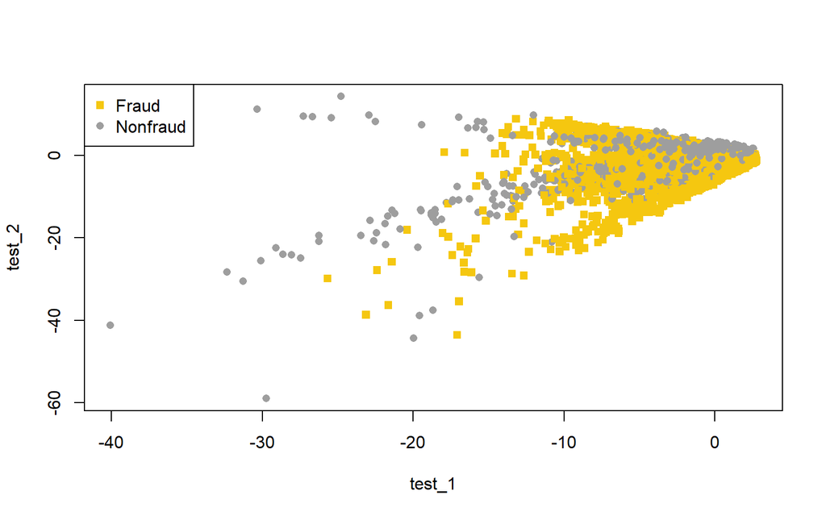

```r
knn = knn(new_df[, -31], test[, -31], new_df[, 31], k = 3)

knn_index = as.numeric(knn)-1
plot(test_1, test_2, pch = knn_index+15, col = knn_index+15)
legend("topleft", legend = c("Fraud", "Nonfraud"), pch = c(15, 16), col = c(15, 16))
```

```r
knn_confmat = confusionMatrix(knn, as.factor(test$Class), positive = "1")
knn_confmat
```

```
## Confusion Matrix and Statistics
##
##           Reference
## Prediction     0     1
##          0 82421     7
##          1  2874   141
##
##                Accuracy : 0.9663
##                  95% CI : (0.965, 0.9675)
##     No Information Rate : 0.9983
##     P-Value [Acc > NIR] : 1
##
##                   Kappa : 0.0861
##
##  Mcnemar's Test P-Value : <2e-16
##
##             Sensitivity : 0.952703
##             Specificity : 0.966305
##          Pos Pred Value : 0.046766
##          Neg Pred Value : 0.999915
##              Prevalence : 0.001732
##          Detection Rate : 0.001650
##    Detection Prevalence : 0.035287
##       Balanced Accuracy : 0.959504
##
##        'Positive' Class : 1
##
```

```r
knn_roc = roc(test$Class, knn_index)
```

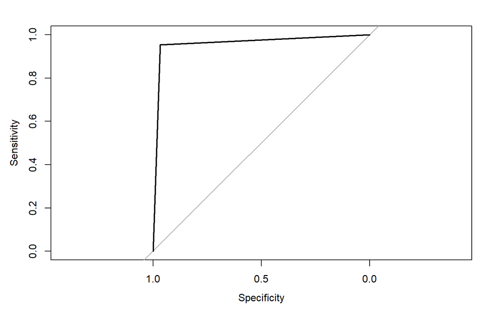

```r
plot(knn_roc)
```

### Random Forest

```r
library(randomForest)
```

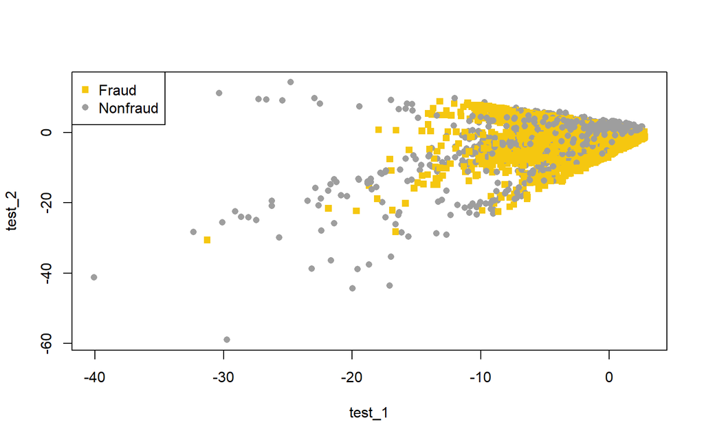

```r
rf = randomForest(Class ~ ., nb_df)
pred_rf = predict(rf, test, type = "class")

rf_index = as.numeric(pred_rf)-1
plot(test_1, test_2, pch = rf_index+15, col = rf_index+15)
legend("topleft", legend = c("Fraud", "Nonfraud"), pch = c(15, 16), col = c(15, 16))
```

```r
rf_confmat = confusionMatrix(pred_rf, as.factor(test$Class), positive = "1")
rf_confmat
```

```
## Confusion Matrix and Statistics
##
##           Reference
## Prediction     0     1
##          0 83205     0
##          1  2090   148
##
##                Accuracy : 0.9755
##                  95% CI : (0.9745, 0.9766)
##     No Information Rate : 0.9983
##     P-Value [Acc > NIR] : 1
##
##                   Kappa : 0.1212
##
##  Mcnemar's Test P-Value : <2e-16
##
##             Sensitivity : 1.000000
##             Specificity : 0.975497
##          Pos Pred Value : 0.066130
##          Neg Pred Value : 1.000000
##              Prevalence : 0.001732
##          Detection Rate : 0.001732
##    Detection Prevalence : 0.026193
##       Balanced Accuracy : 0.987748
##
##        'Positive' Class : 1
##
```

```r
rf_roc = roc(test$Class ~ rf_index)
```

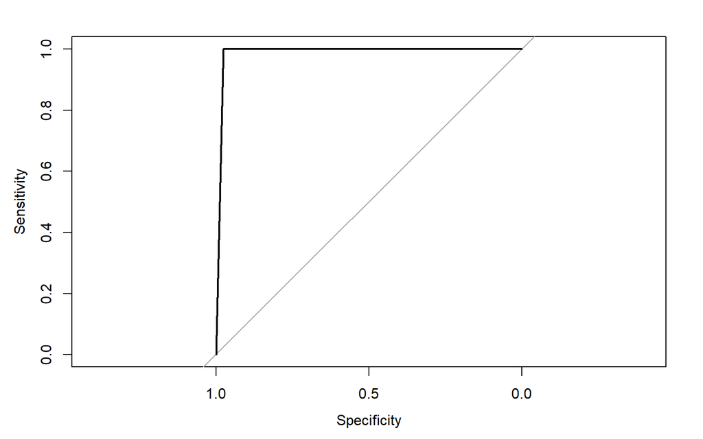

```r
plot(rf_roc)
```

### Gradient Boosting

```r
library(gbm)
```

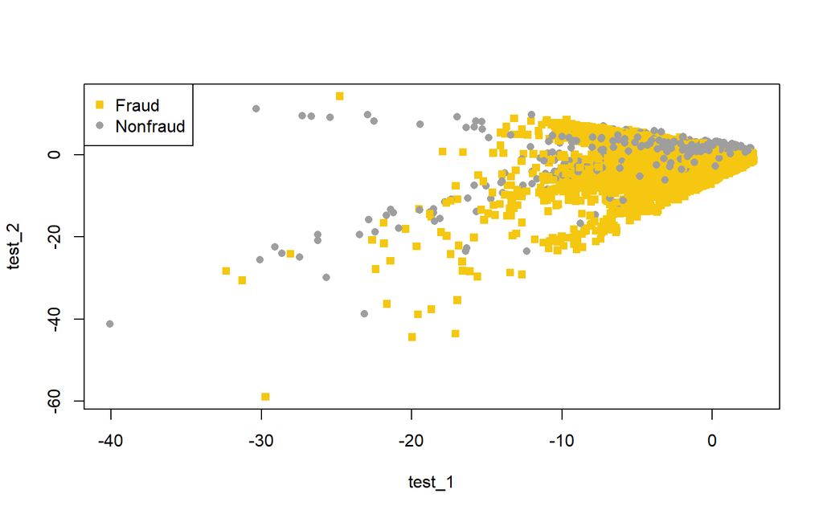

```r
gbm = gbm(Class ~ ., data = new_df, distribution = "bernoulli")
pred_gbm = predict(gbm, test, n.trees = 100, type = "response")
gbm_index = as.numeric(pred_gbm > .9)

plot(test_1, test_2, pch = gbm_index+15, col = gbm_index+15)
legend("topleft", legend = c("Fraud", "Nonfraud"), pch = c(15, 16), col = c(15, 16))
```

```r
gbm_confmat = confusionMatrix(as.factor(gbm_index), as.factor(test$Class), positive = "1")
gbm_confmat
```

```
## Confusion Matrix and Statistics
##
##           Reference
## Prediction     0     1
##          0 84575    18
##          1   720   130
##
##                Accuracy : 0.9914
##                  95% CI : (0.9907, 0.992)
##     No Information Rate : 0.9983
##     P-Value [Acc > NIR] : 1
##
##                   Kappa : 0.2583
##
##  Mcnemar's Test P-Value : <2e-16
##
##             Sensitivity : 0.878378
##             Specificity : 0.991559
##          Pos Pred Value : 0.152941
##          Neg Pred Value : 0.999787
##              Prevalence : 0.001732
##          Detection Rate : 0.001521
##    Detection Prevalence : 0.009948
##       Balanced Accuracy : 0.934969
##
##        'Positive' Class : 1
##
```

```r
gbm_roc = roc(test$Class ~ gbm_index)
```

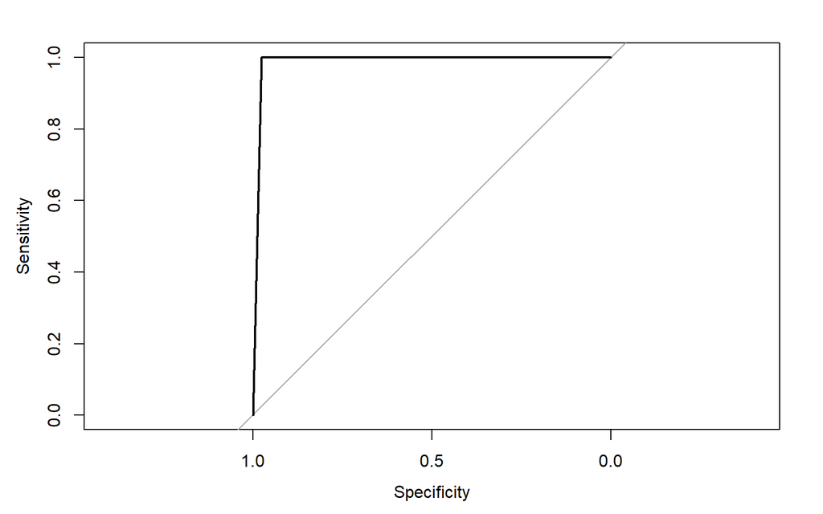

```r
plot(rf_roc)
```

## Undersample summary

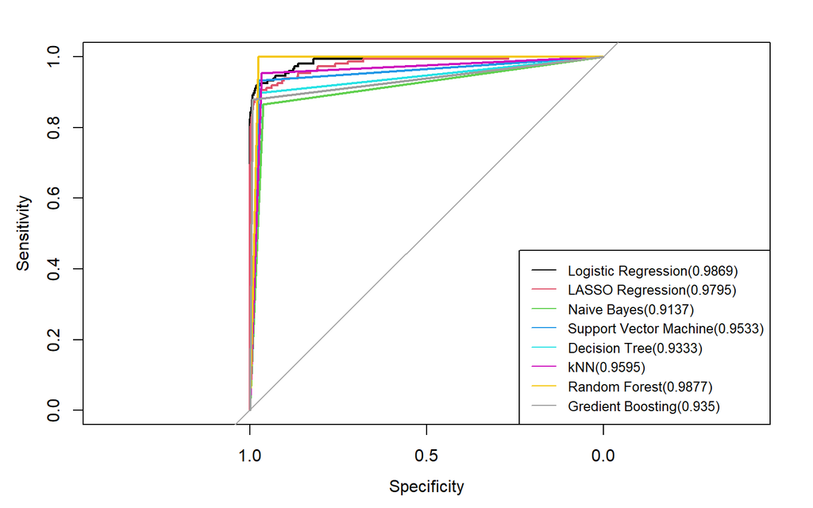

```r
legends = c("Logistic Regression", "LASSO Regression", "Naive Bayes", "Support Vector Machine",
            "Decision Tree", "kNN", "Random Forest", "Gredient Boosting")
auc = round(c(lr_roc$auc, lasso_roc$auc, nb_roc$auc, svm_roc$auc, dt_roc$auc, knn_roc$auc,
              rf_roc$auc, gbm_roc$auc), 4)
legends = paste(legends, rep("(", 8), auc, rep(")", 8), sep = "")

# roc curves
plot(lr_roc, col = 1)
lines(lasso_roc, col = 2)
lines(nb_roc, col = 3)
lines(svm_roc, col = 4)
lines(dt_roc, col = 5)
lines(knn_roc, col = 6)
lines(rf_roc, col = 7)
lines(gbm_roc, col = 8)
legend("bottomright", legend = legends, col = 1:8, lty = "solid", cex = .8)
```

# SMOTE: Oversampling

```r
library(DMwR)
train$Class = as.factor(train$Class)

smote_df = SMOTE(Class ~ ., train, perc.over = 1000, perc.under = 300, k = 5)
table(smote_df$Class)
```

```
##
##     0     1
## 10320  3784
```

By oversampling, we can fully exploit the information without loss. This method will result in better accuracy than random under-sampling.

```r
lr_smote = glm(Class ~ ., smote_df, family = "binomial")
```

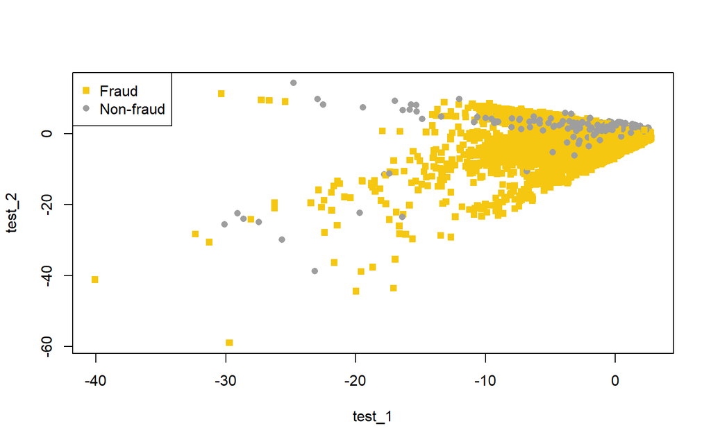

```r
pred_lr_smote = predict(lr_smote, newdata = test, type = "response")
lr_smote_index = as.numeric(pred_lr_smote > 0.9) # cutoff

plot(test_1, test_2, pch = lr_smote_index+15, col = lr_smote_index+15)
legend("topleft", legend = c("Fraud", "Non-fraud"), pch = c(15, 16), col = c(15, 16))
```

```r
lr_smote_confmat = confusionMatrix(as.factor(lr_smote_index), as.factor(test$Class), positive = "1")
lr_smote_confmat
```

```
## Confusion Matrix and Statistics
##
##           Reference
## Prediction     0     1
##          0 85063    28
##          1   232   120
##
##                Accuracy : 0.997
##                  95% CI : (0.9966, 0.9973)
##     No Information Rate : 0.9983
##     P-Value [Acc > NIR] : 1
##
##                   Kappa : 0.4787
##
##  Mcnemar's Test P-Value : <2e-16
##
##             Sensitivity : 0.810811
##             Specificity : 0.997280
##          Pos Pred Value : 0.340909
##          Neg Pred Value : 0.999671
##              Prevalence : 0.001732
##          Detection Rate : 0.001404
##    Detection Prevalence : 0.004120
##       Balanced Accuracy : 0.904045
##
##        'Positive' Class : 1
##
```

```r
lr_smote_roc = roc(test$Class ~ pred_lr_smote)
```

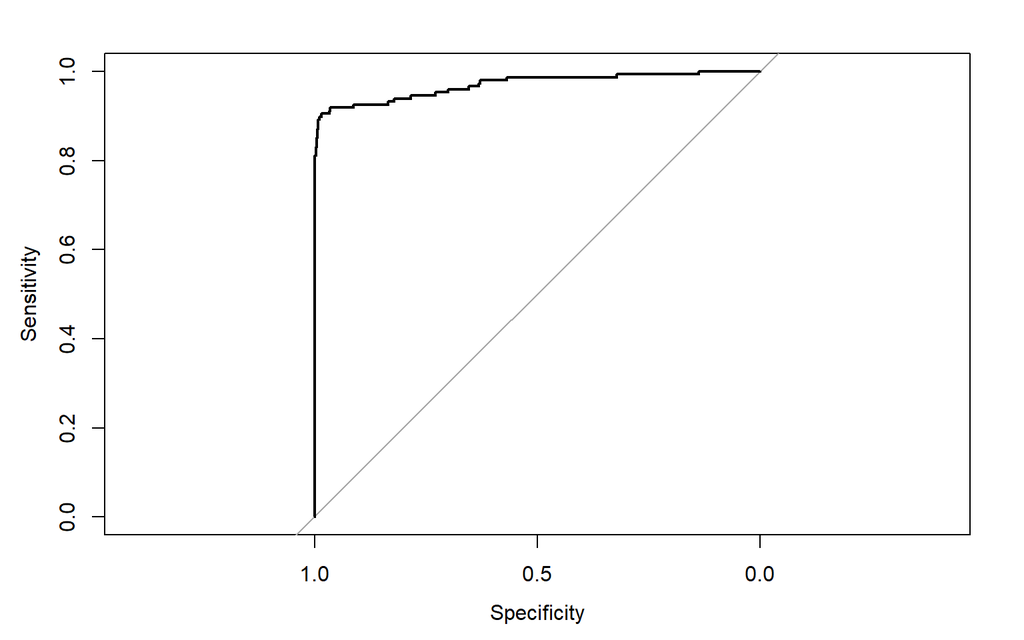

```r
plot(lr_smote_roc)
```

# Total summary

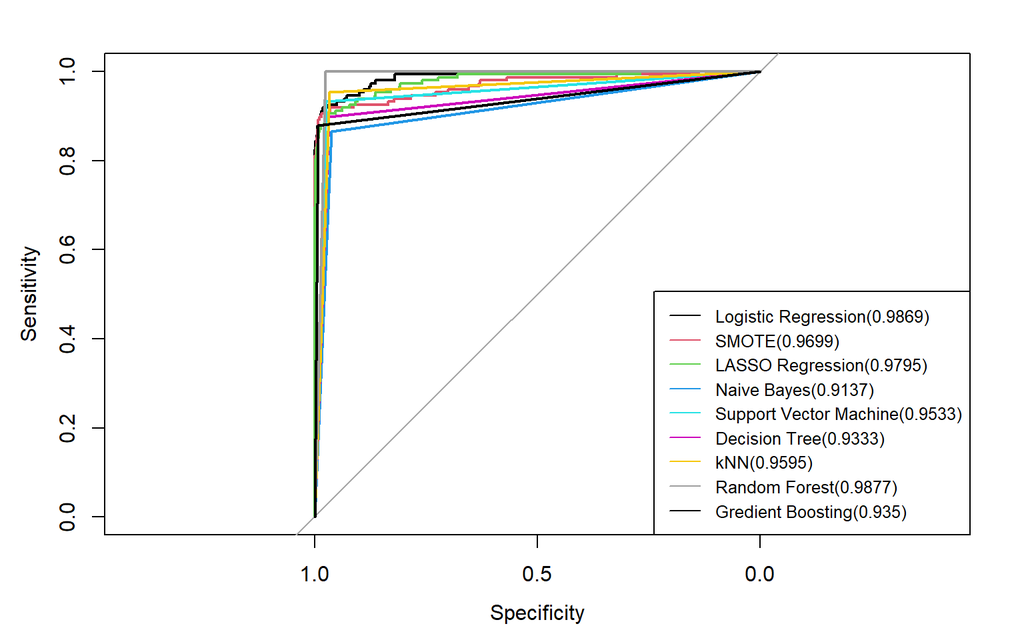

```r
legends = c("Logistic Regression", "SMOTE", "LASSO Regression", "Naive Bayes", "Support Vector Machine",
            "Decision Tree", "kNN", "Random Forest", "Gredient Boosting")
auc = round(c(lr_roc$auc, lr_smote_roc$auc, lasso_roc$auc, nb_roc$auc, svm_roc$auc,
              dt_roc$auc, knn_roc$auc, rf_roc$auc, gbm_roc$auc), 4)
legends_auc = paste(legends, rep("(", 9), auc, rep(")", 9), sep = "")

# roc curves
plot(lr_roc, col = 1)
lines(lr_smote_roc, col = 2)
lines(lasso_roc, col = 3)
lines(nb_roc, col = 4)
lines(svm_roc, col = 5)
lines(dt_roc, col = 6)
lines(knn_roc, col = 7)
lines(rf_roc, col = 8)
lines(gbm_roc, col = 9)
legend("bottomright", legend = legends_auc, col = 1:9, lty = "solid", cex = .8)
```

```r
# performance
perf = data.frame(Method = legends,
                  Accuracy = c(lr_confmat$overall['Accuracy'], lr_smote_confmat$overall['Accuracy'],
                               lasso_confmat$overall['Accuracy'], nb_confmat$overall['Accuracy'],
                               svm_confmat$overall['Accuracy'], dt_confmat$overall['Accuracy'],
                               knn_confmat$overall['Accuracy'], rf_confmat$overall['Accuracy'],
                               gbm_confmat$overall['Accuracy']),
                  Sensitivity = c(lr_confmat$byClass['Sensitivity'], lr_smote_confmat$byClass['Sensitivity'],
                                  lasso_confmat$byClass['Sensitivity'], nb_confmat$byClass['Sensitivity'],
                                  svm_confmat$byClass['Sensitivity'], dt_confmat$byClass['Sensitivity'],
                                  knn_confmat$byClass['Sensitivity'], rf_confmat$byClass['Sensitivity'],
                                  gbm_confmat$byClass['Sensitivity']),
                  Specificity = c(lr_confmat$byClass['Specificity'], lr_smote_confmat$byClass['Specificity'],
                                  lasso_confmat$byClass['Specificity'], nb_confmat$byClass['Specificity'],
                                  svm_confmat$byClass['Specificity'], dt_confmat$byClass['Specificity'],
                                  knn_confmat$byClass['Specificity'], rf_confmat$byClass['Specificity'],
                                  gbm_confmat$byClass['Specificity']),
                  AUC = c(lr_roc$auc, lr_smote_roc$auc, lasso_roc$auc, nb_roc$auc, svm_roc$auc,
                          dt_roc$auc, knn_roc$auc, rf_roc$auc, gbm_roc$auc)
                  )
perf
```

```
##                   Method  Accuracy Sensitivity Specificity       AUC
## 1    Logistic Regression 0.9897124   0.8918919   0.9898822 0.9868976
## 2                  SMOTE 0.9969570   0.8108108   0.9972800 0.9699228
## 3       LASSO Regression 0.9976007   0.7837838   0.9979717 0.9794981
## 4            Naive Bayes 0.9624311   0.8648649   0.9626004 0.9137326
## 5 Support Vector Machine 0.9740178   0.9324324   0.9740899 0.9532612
## 6          Decision Tree 0.9677329   0.8986486   0.9678527 0.9332507
## 7                    kNN 0.9662816   0.9527027   0.9663052 0.9595039
## 8          Random Forest 0.9755392   1.0000000   0.9754968 0.9877484
## 9      Gredient Boosting 0.9913627   0.8783784   0.9915587 0.9349685
```

Surprisingly, SMOTE performed worse than simple logistic regression in terms of sensitivity and AUC, whereas accuracy is better. This maybe is due to the failure to optimize parameters.  
Overall, LASSO performed the best in terms of accuracy, random forest in terms of sensitivity, LASSO regression in terms of specificity, and random forest in terms of AUC. Considering that wrongly classifying a nonfraud as a fraud and enforcing measures may cause bigger hassle and costs than wrongly classifying a fraud as nonfraud, we can say specificity is more important here. Then, LASSO regression seems to be the model we are looking for, although random forest may come in handy if we really want to catch the frauds.